# STATS 503 Group Project

How will the Trump tweets affect daily stock prices?

Group 14 - Xiaolin Cao, Ting-Wei Lin, Ming-Chen Lu, Suzy McTaggart

April 14, 2020

# Data Exploration

1. What time of day the tweets occur?

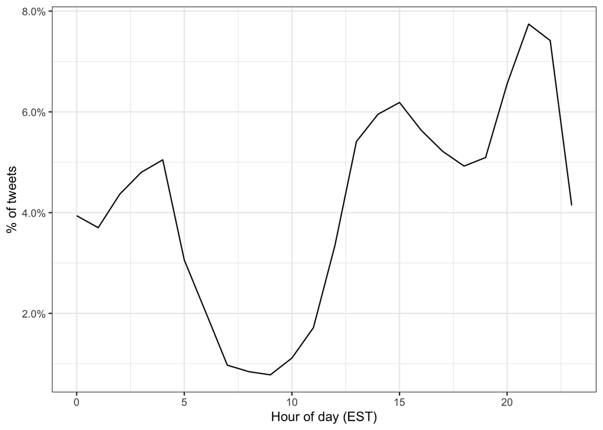

# Data Preprocessing

Difference in the *content*?

What were the most common words in Trump’s tweets overall?

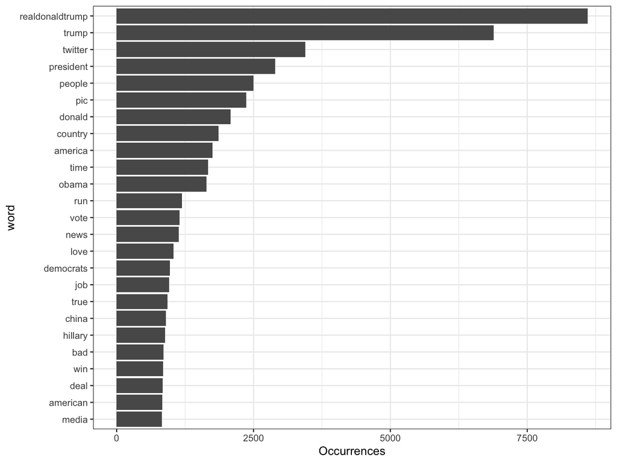

# Sentiment Analysis

We’ll work with the [NRC Word-Emotion Association](http://saifmohammad.com/WebPages/NRC-Emotion-Lexicon.htm) lexicon, available from the tidytext package, which associates words with 10 sentiments: **positive**, **negative**, **anger**, **anticipation**, **disgust**, **fear**, **joy**, **sadness**, **surprise**, and **trust**.

Count the number of words in each category:

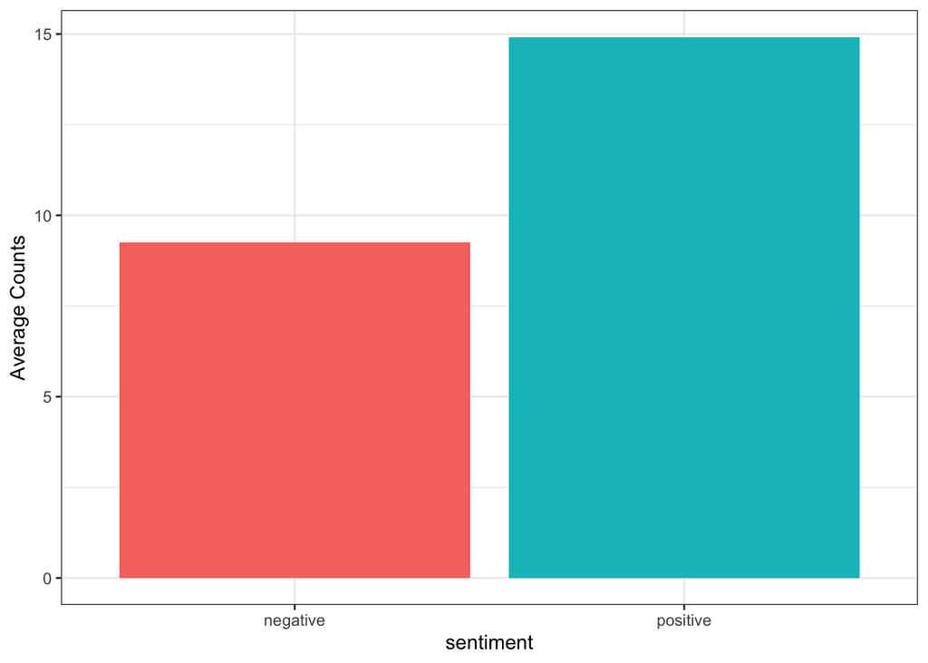

**Note: Twitter limits its length to 280 characters. 280 characters is about 55 words if you use 5.1 words as the average word length.**

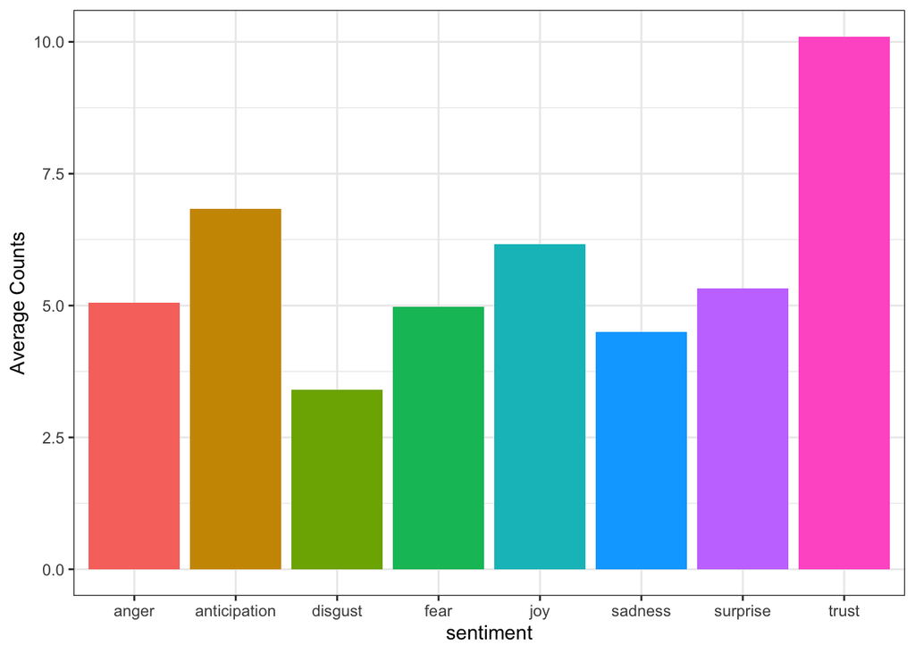

Words associated with **trust** have the highest frequency of occurrence, followed by **anticipation**, **joy**, and then **surprise** and **anger**. This word association seems to correspond to the public image of Trump from the media.

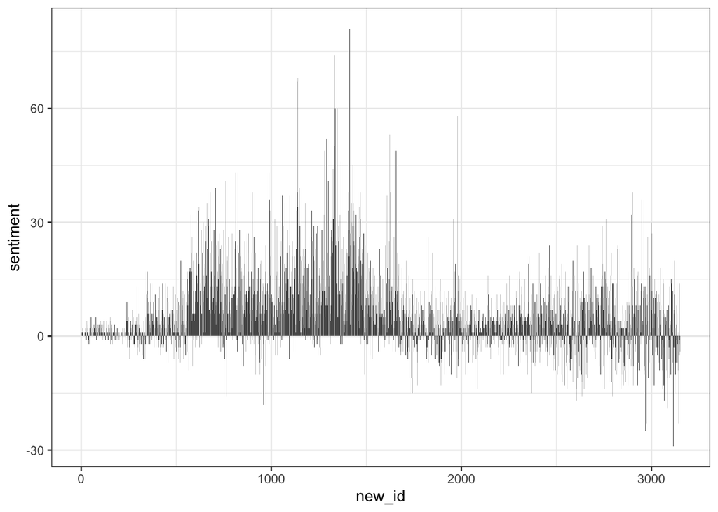

## Most common positive and negative words

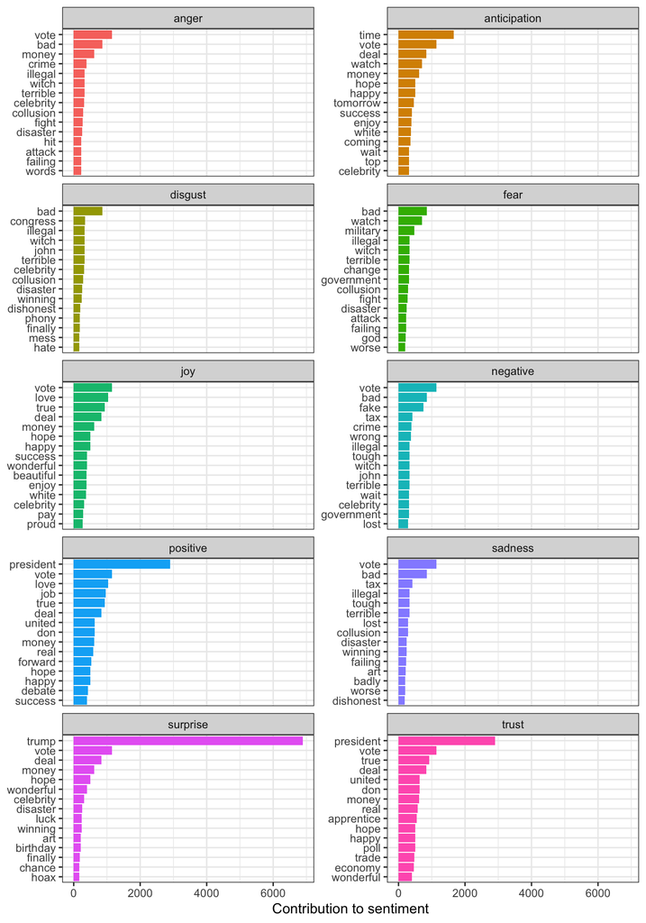

# Classifier Learning

```
##
## Call:
##  randomForest(formula = delta_day1 ~ ss_compound + retweets +      favorites + Adj.Close + anger + anticipation + disgust +      fear + joy + sadness + surprise + trust, data = df, mtry = ncol(df) -      1, importance = TRUE, ntree = 500)
##                Type of random forest: classification
##                      Number of trees: 500
## No. of variables tried at each split: 12
##
##         OOB estimate of  error rate: 48.21%
## Confusion matrix:
##     0   1 class.error
## 0 404 633   0.6104147
## 1 446 755   0.3713572
```

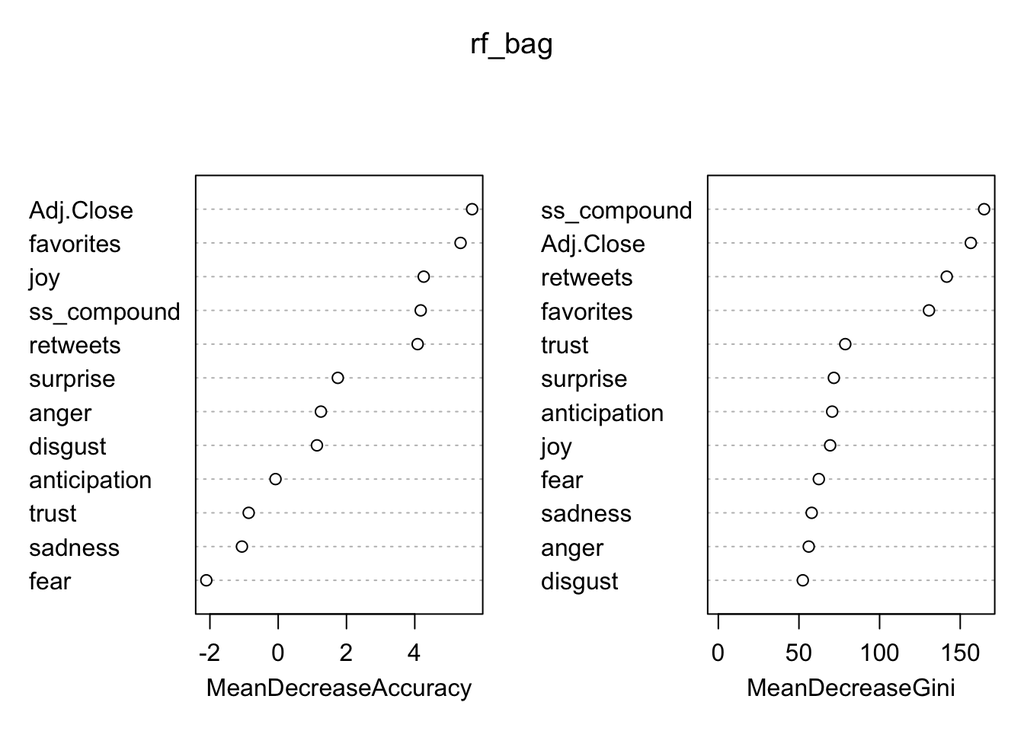

# References

- Sentiment analysis of Trump’s tweets with R https://blog.revolutionanalytics.com/2016/08/sentiment-analysis-of-trumps-tweets-with-r.html
- https://github.com/dgrtwo/dgrtwo.github.com/blob/master/_R/2016-08-09-trump-tweets.Rmd
- https://medium.com/@tomyuz/a-sentiment-analysis-approach-to-predicting-stock-returns-d5ca8b75a42